# HW3

Dmitry Panteleev

2024-05-13

Data on lizard hematology were collected from September through November 2010 at few sites with varying degrees of anthropogenic landscape modification (data in file Sleepy lizard.xlsx, sheet “data”). In the unmodified landscape (Treatment 1), samples were collected in one BS0 study area (Landscape.ID 1). In the heavily modified landscape (Treatment 2), samples were collected in three different neighborhoods (Landscape.ID 1 - LS1, 3 - LS2, 5 - LS3).

Only in the heavily modified landscape in each neighborhood were sites categorized into groups based on habitat type (Habitat: remnants of natural vegetation, swale plantings, fields with crops or under fallow) and the degree of connectivity with patches of natural vegetation (Connectivity: low < 63%, medium 63-88%, high 88%; fully connected sites).

```r
lizard<-read_excel(path ="lizard.xlsx")
```

```r
colnames(lizard)
```

```
##  [1] "Record#"      "Animal #"     "CumDays"      "Treatment"    "Habitat"
##  [6] "Landscape ID" "Connectivity" "Age"          "LBSI"         "SVL (mm)"
## [11] "WT_(g)"       "#_Ticks"      "Tot_WBC"      "Het_ABS"      "Lym_ABS"
## [16] "H:L Ratio"    "Mon_ABS"      "OthG_ABS"     "Het_%"        "Lym_%"
## [21] "Mon_%"        "OthG_%"       "Poly_%"
```

```r
# Columns that will be investigated in our study.

nes_cols <- c("Tot_WBC","Het_ABS","Lym_ABS","H:L Ratio","Mon_ABS","OthG_ABS")
```

```r
lizard$Treatment<-as.factor(lizard$Treatment)
lizard$Habitat<-as.factor(lizard$Habitat)
lizard$Connectivity<-as.factor(lizard$Connectivity)
```

```r
lizard<-lizard[-c(3)]
```

We need to find a difference between quantitative parameters and environmental characteristics for each task. For this purpose, we can use the perMANOVA test because our data is multidimensional. It is more comfortable method than MANOVA because haven’t some prerequisites.

### Exploratory step of continious data

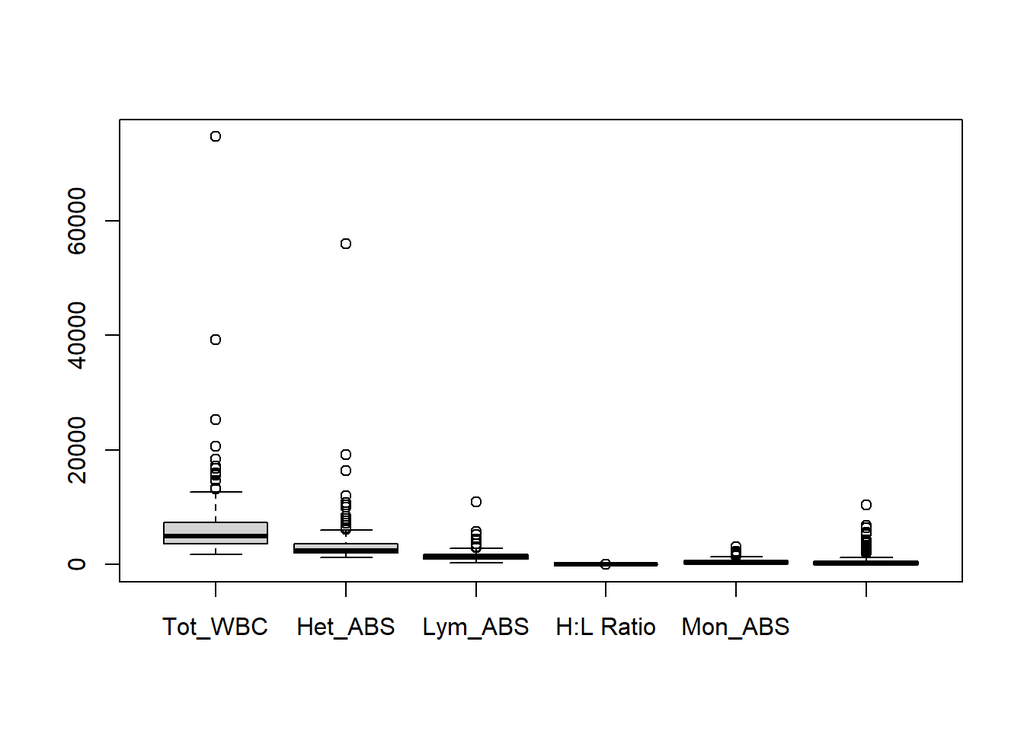

```r
boxplot(lizard[nes_cols])
```

### Log transformation and centralizing

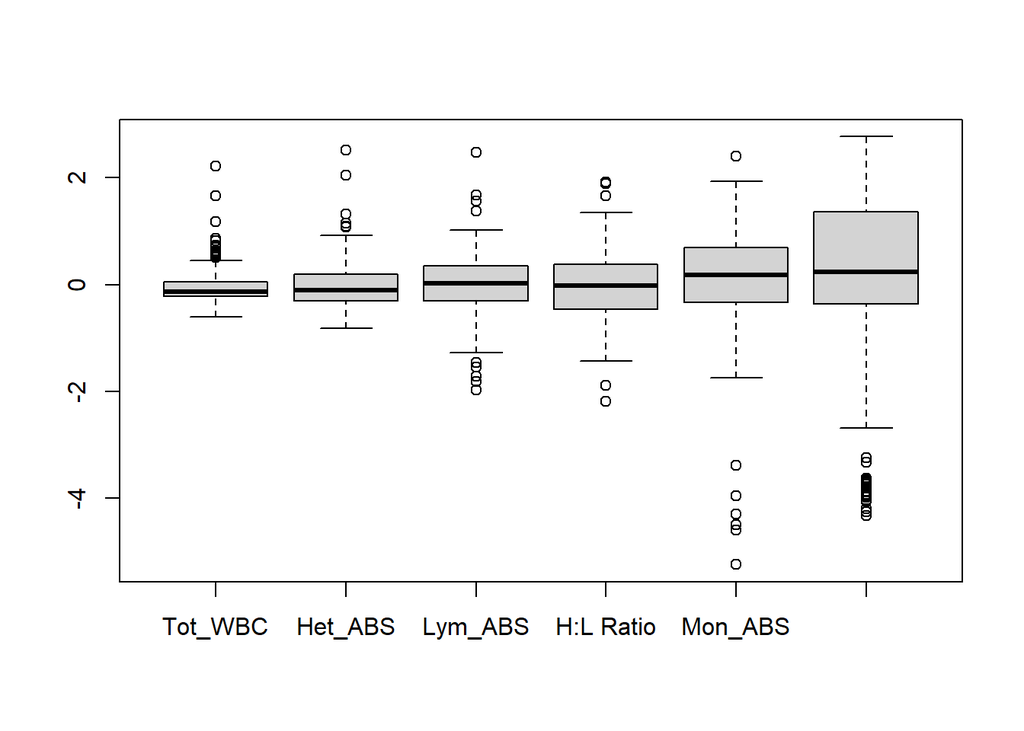

```r
log_lizard <- log(lizard[nes_cols]+1)

center <- function(x){
  x - mean(x, na.rm = TRUE)
}


lz_cent <- t(apply(log_lizard, 1, center))

center_log_lizard <- apply(t(lz_cent), 1, center)

boxplot(center_log_lizard)
```

Equality of variance in groups is necessary for perMANOVA.

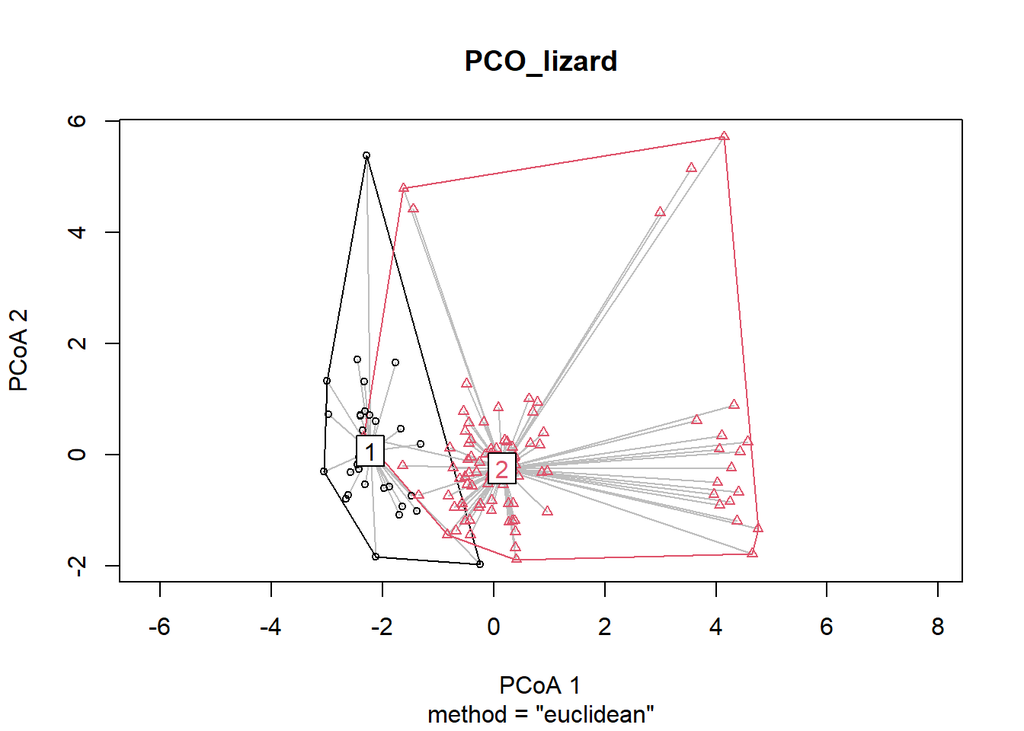

```r
dist_lizard <- vegdist(center_log_lizard, method  = "euclidean")
PCO_lizard <- betadisper(dist_lizard, lizard$Treatment)
plot(PCO_lizard)
```

```r
anova(PCO_lizard)
```

```
## Analysis of Variance Table
##
## Response: Distances
##            Df  Sum Sq Mean Sq F value Pr(>F)
## Groups      1   2.093  2.0928  0.9336 0.3359
## Residuals 120 268.983  2.2415
```

Ho is true. The variances of groups are equal.

## Task 1

### a:

Does the blood composition of lizards from unmodified and heavily modified landscapes differ?

Check equality of variance:

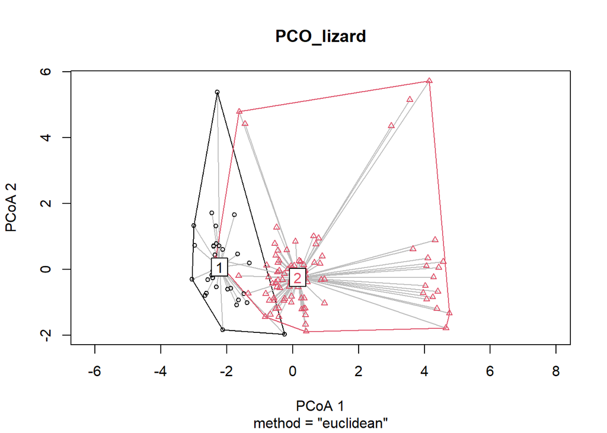

```r
dist_lizard <- vegdist(center_log_lizard, method  = "euclidean")
PCO_lizard <- betadisper(dist_lizard, lizard$Treatment)
plot(PCO_lizard)
```

```r
anova(PCO_lizard)
```

```
## Analysis of Variance Table
##
## Response: Distances
##            Df  Sum Sq Mean Sq F value Pr(>F)
## Groups      1   2.093  2.0928  0.9336 0.3359
## Residuals 120 268.983  2.2415
```

Ho is true. The variances of groups are equal.

```r
permanova_lizard <- adonis2(center_log_lizard ~ lizard$Treatment, method = "euclidean")
permanova_lizard
```

```
## Permutation test for adonis under reduced model
## Terms added sequentially (first to last)
## Permutation: free
## Number of permutations: 999
##
## adonis2(formula = center_log_lizard ~ lizard$Treatment, method = "euclidean")
##                   Df SumOfSqs      R2      F Pr(>F)
## lizard$Treatment   1   187.99 0.24279 38.477  0.001 ***
## Residual         120   586.30 0.75721
## Total            121   774.29 1.00000
## ---
## Signif. codes:  0 '***' 0.001 '**' 0.01 '*' 0.05 '.' 0.1 ' ' 1
```

Answer: Yes, we have the difference in the the blood composition of lizards from unmodified and heavily modified landscapes.

We have only 2 groups that is why we don’t need to perform a post hoc test.

### b:

Check whether blood composition of lizards in different habitats differs between lizards from the highly modified landscape.

df with only samples from the highly modified landscape:

```r
lizard_2 <- lizard[lizard$Treatment == 2,]
```

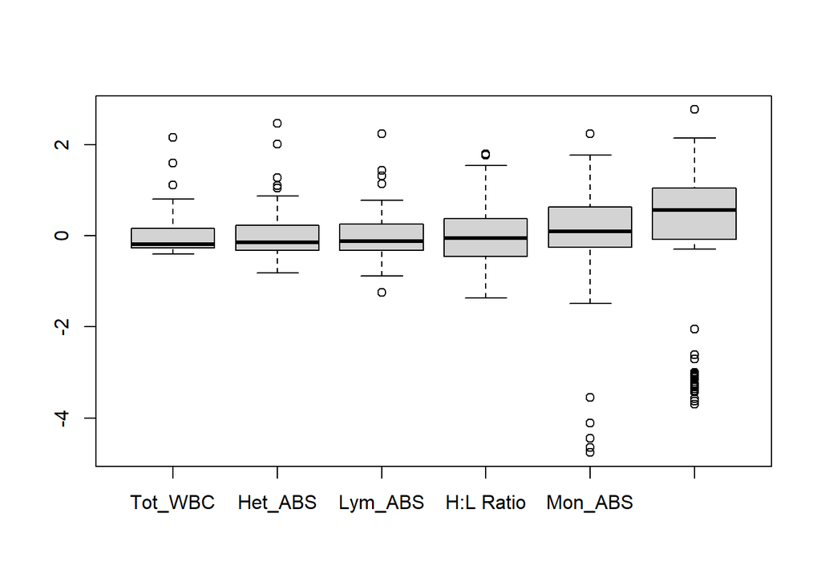

```r
log_lizard <- log(lizard_2[nes_cols]+1)

center <- function(x){
  x - mean(x, na.rm = TRUE)
}


lz_cent <- t(apply(log_lizard, 1, center))

center_log_lizard <- apply(t(lz_cent), 1, center)

boxplot(center_log_lizard)
```

Check equality of variance:

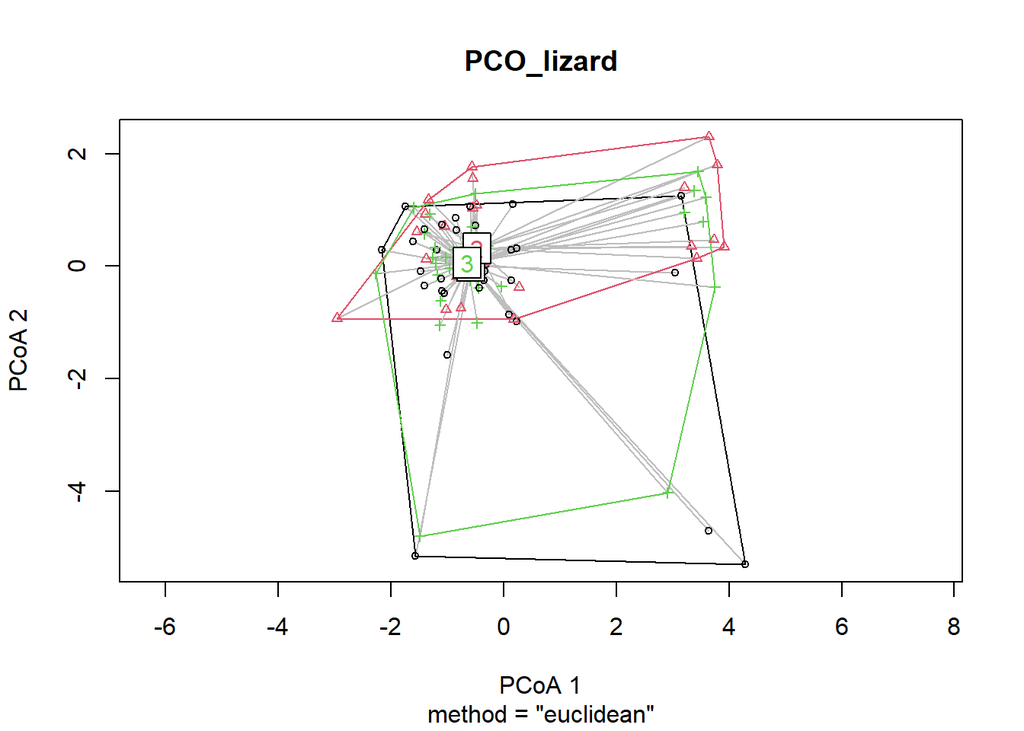

```r
dist_lizard <- vegdist(center_log_lizard, method  = "euclidean")
PCO_lizard <- betadisper(dist_lizard, lizard_2$Habitat)
plot(PCO_lizard)
```

```r
anova(PCO_lizard)
```

```
## Analysis of Variance Table
##
## Response: Distances
##           Df  Sum Sq Mean Sq F value Pr(>F)
## Groups     2   1.669 0.83444  0.3125 0.7324
## Residuals 89 237.674 2.67050
```

Ho is true. The variances of groups are equal.

```r
permanova_lizard <- adonis2(center_log_lizard ~ lizard_2$Habitat, method = "euclidean")
permanova_lizard
```

```
## Permutation test for adonis under reduced model
## Terms added sequentially (first to last)
## Permutation: free
## Number of permutations: 999
##
## adonis2(formula = center_log_lizard ~ lizard_2$Habitat, method = "euclidean")
##                  Df SumOfSqs      R2      F Pr(>F)
## lizard_2$Habitat  2    14.05 0.02825 1.2938  0.268
## Residual         89   483.32 0.97175
## Total            91   497.37 1.00000
```

That is why we don’t need to perform a post hoc test.

### c

Test whether the degree of connectivity affects the blood composition of lizards from the highly modified landscape.

df with only samples from the highly modified landscape:

```r
lizard_2 <- lizard[lizard$Treatment == 2,]
```

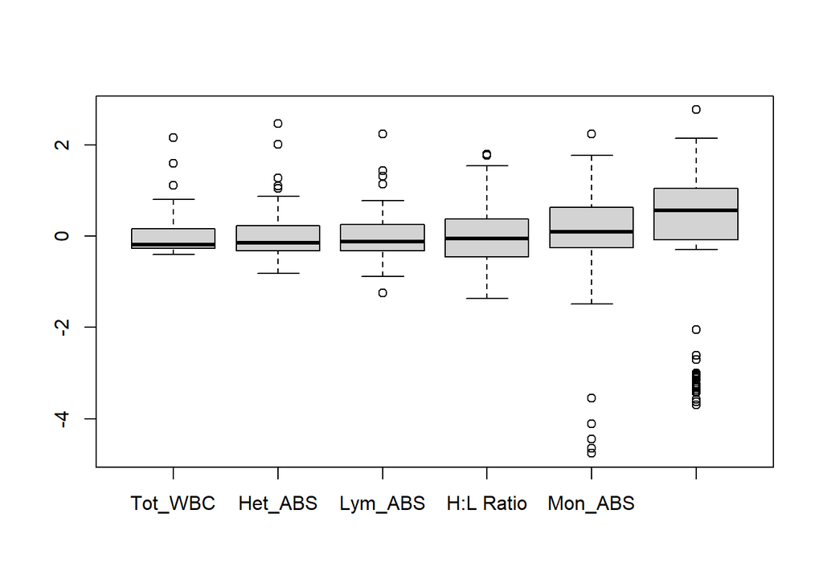

```r
log_lizard <- log(lizard_2[nes_cols]+1)

center <- function(x){
  x - mean(x, na.rm = TRUE)
}


lz_cent <- t(apply(log_lizard, 1, center))

center_log_lizard <- apply(t(lz_cent), 1, center)

boxplot(center_log_lizard)
```

Check equality of variance:

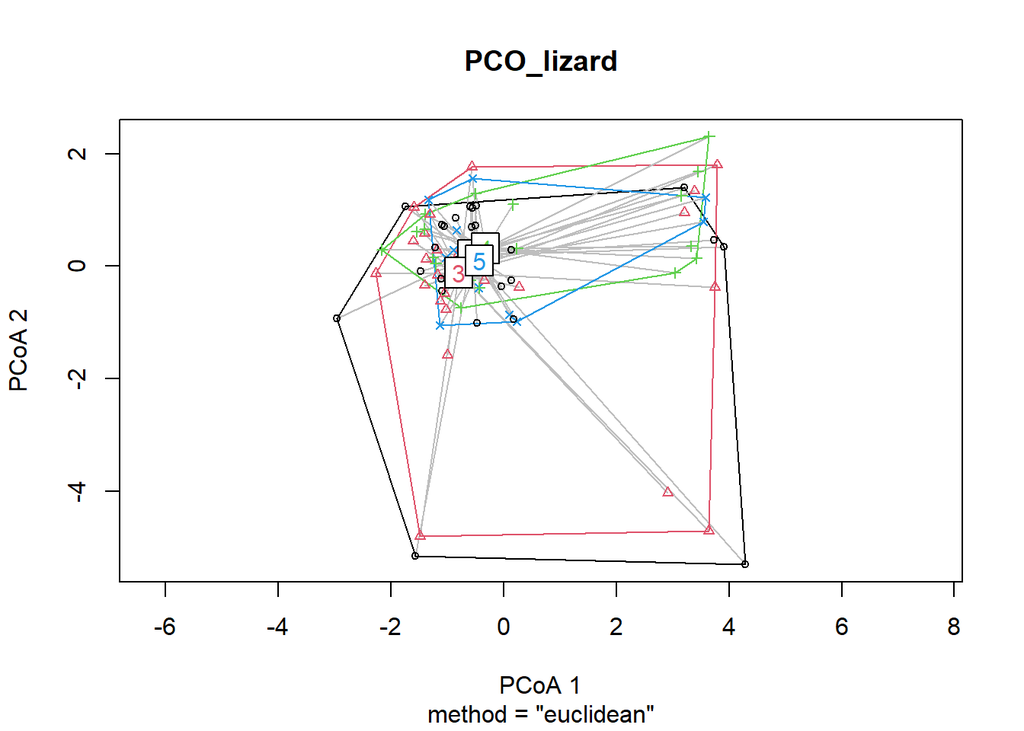

```r
dist_lizard <- vegdist(center_log_lizard, method  = "euclidean")
PCO_lizard <- betadisper(dist_lizard, lizard_2$Connectivity)
plot(PCO_lizard)
```

```r
anova(PCO_lizard)
```

```
## Analysis of Variance Table
##
## Response: Distances
##           Df  Sum Sq Mean Sq F value Pr(>F)
## Groups     3   1.458 0.48608  0.1777 0.9112
## Residuals 88 240.650 2.73466
```

Ho is true. The variances of groups are equal.

```r
permanova_lizard <- adonis2(center_log_lizard ~ lizard_2$Connectivity, method = "euclidean")
permanova_lizard
```

```
## Permutation test for adonis under reduced model
## Terms added sequentially (first to last)
## Permutation: free
## Number of permutations: 999
##
## adonis2(formula = center_log_lizard ~ lizard_2$Connectivity, method = "euclidean")
##                       Df SumOfSqs     R2      F Pr(>F)
## lizard_2$Connectivity  3    13.58 0.0273 0.8233  0.544
## Residual              88   483.79 0.9727
## Total                 91   497.37 1.0000
```

That is why we don’t need to perform a post hoc test.

## Task 2

### d

I decided to create new column with data from treatment, habitat and degree of connectivity columns simulteniously.

```r
colnames(lizard)
```

```
##  [1] "Record#"      "Animal #"     "Treatment"    "Habitat"      "Landscape ID"
##  [6] "Connectivity" "Age"          "LBSI"         "SVL (mm)"     "WT_(g)"
## [11] "#_Ticks"      "Tot_WBC"      "Het_ABS"      "Lym_ABS"      "H:L Ratio"
## [16] "Mon_ABS"      "OthG_ABS"     "Het_%"        "Lym_%"        "Mon_%"
## [21] "OthG_%"       "Poly_%"
```

```r
cols = c("Treatment","Habitat","Connectivity")

lizard$gen_col_T_H_C <- do.call(paste, c(lizard[cols], sep = "_"))
```

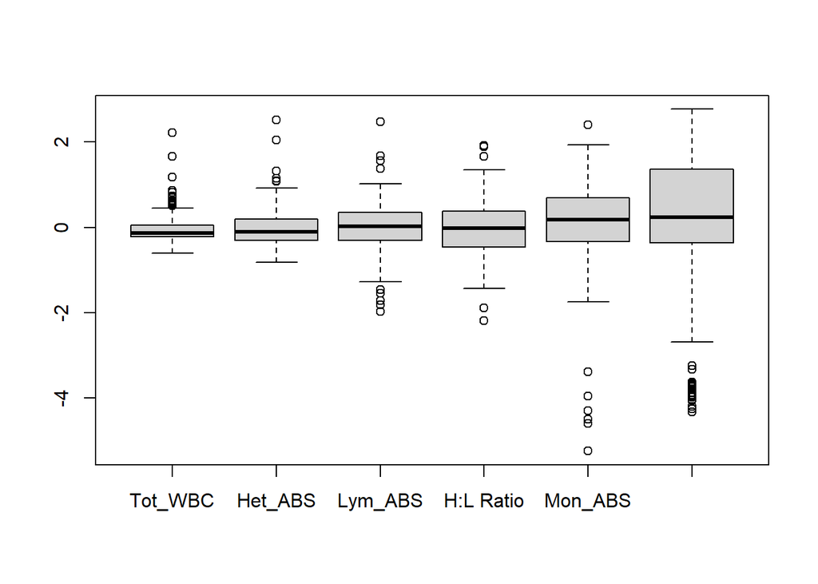

```r
log_lizard <- log(lizard[nes_cols]+1)

center <- function(x){
  x - mean(x, na.rm = TRUE)
}


lz_cent <- t(apply(log_lizard, 1, center))

center_log_lizard <- apply(t(lz_cent), 1, center)

boxplot(center_log_lizard)
```

Check equality of variance:

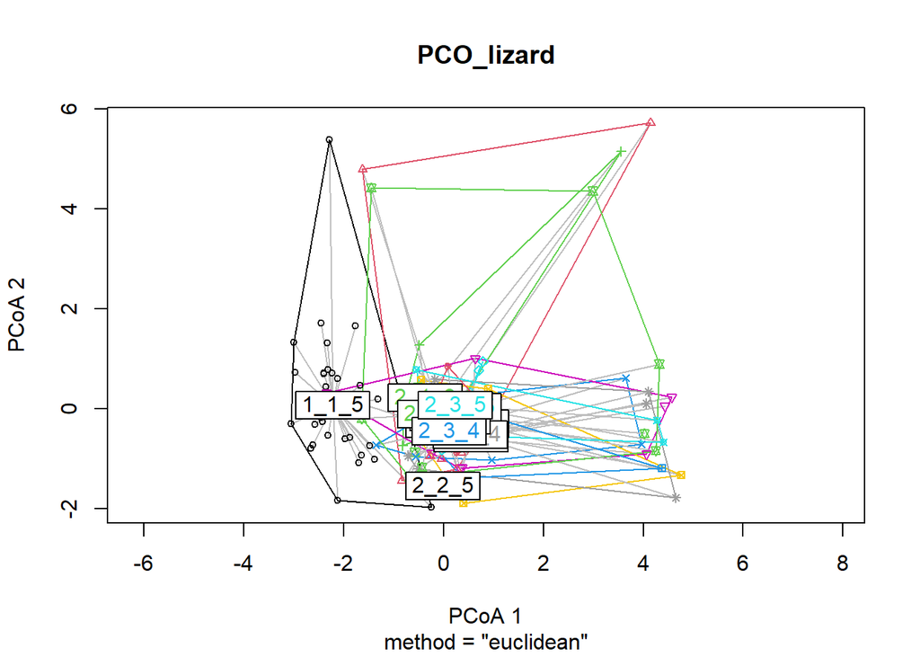

```r
dist_lizard <- vegdist(center_log_lizard, method  = "euclidean")
PCO_lizard <- betadisper(dist_lizard, lizard$gen_col_T_H_C)
plot(PCO_lizard)
```

```r
anova(PCO_lizard)
```

```
## Analysis of Variance Table
##
## Response: Distances
##            Df  Sum Sq Mean Sq F value Pr(>F)
## Groups     12  27.256  2.2713  1.0136 0.4417
## Residuals 109 244.250  2.2408
```

Ho is true. The variances of groups are equal.

```r
permanova_lizard <- adonis2(center_log_lizard ~ lizard$gen_col_T_H_C, method = "euclidean")
permanova_lizard
```

```
## Permutation test for adonis under reduced model
## Terms added sequentially (first to last)
## Permutation: free
## Number of permutations: 999
##
## adonis2(formula = center_log_lizard ~ lizard$gen_col_T_H_C, method = "euclidean")
##                       Df SumOfSqs      R2      F Pr(>F)
## lizard$gen_col_T_H_C  12   233.74 0.30188 3.9278  0.001 ***
## Residual             109   540.55 0.69812
## Total                121   774.29 1.00000
## ---
## Signif. codes:  0 '***' 0.001 '**' 0.01 '*' 0.05 '.' 0.1 ' ' 1
```

Answer: Yes, we have the difference in the the blood composition of lizards, however, in this case there are multiple groups that are compared that is why we have to perform a post hoc test and adjust p value:

```r
pairwise_permanova <- function(dat, group, strata = NULL, ...){
  pair <- combn(unique(as.character(group)), 2)
  ncomb <- ncol(pair)
  res <- rep(NA, ncomb)
  for (i in 1:ncomb) {
    filter <- group %in% pair[, i]
    if(is.null(strata)){
      posthoc <- adonis(dat[filter, ] ~ group[filter], ...)$aov.tab$Pr[1]
    } else {
      posthoc <- adonis(dat[filter, ] ~ group[filter],
                        strata = strata[filter], ...)$aov.tab$Pr[1]
    }
    res[i] <- posthoc
    names(res)[i] <- paste(pair[, i], collapse = " vs. ")
  }
  return(res)
}
```

```r
p_vals <- pairwise_permanova(
  dat = center_log_lizard, group = lizard$gen_col_T_H_C,
  method = "euclidean", permutations=99999)
p_vals
```

```
## 1_1_5 vs. 2_3_5 1_1_5 vs. 2_3_4 1_1_5 vs. 2_1_1 1_1_5 vs. 2_3_1 1_1_5 vs. 2_2_5
##      0.00001000      0.00001000      0.00001000      0.00007000      0.03615000
## 1_1_5 vs. 2_2_1 1_1_5 vs. 2_1_3 1_1_5 vs. 2_1_4 1_1_5 vs. 2_2_3 1_1_5 vs. 2_1_5
##      0.00001000      0.00043000      0.00001000      0.00001000      0.00033000
## 1_1_5 vs. 2_3_3 1_1_5 vs. 2_2_4 2_3_5 vs. 2_3_4 2_3_5 vs. 2_1_1 2_3_5 vs. 2_3_1
##      0.00001000      0.00001000      0.68821000      0.34205000      0.43817000
## 2_3_5 vs. 2_2_5 2_3_5 vs. 2_2_1 2_3_5 vs. 2_1_3 2_3_5 vs. 2_1_4 2_3_5 vs. 2_2_3
##      0.25000000      0.98885000      0.29000000      0.80174000      0.52283000
## 2_3_5 vs. 2_1_5 2_3_5 vs. 2_3_3 2_3_5 vs. 2_2_4 2_3_4 vs. 2_1_1 2_3_4 vs. 2_3_1
##      0.50385000      0.76878000      0.82511000      0.41169000      0.69508000
## 2_3_4 vs. 2_2_5 2_3_4 vs. 2_2_1 2_3_4 vs. 2_1_3 2_3_4 vs. 2_1_4 2_3_4 vs. 2_2_3
##      0.46428571      0.69503000      0.28112000      0.81141000      0.90801000
## 2_3_4 vs. 2_1_5 2_3_4 vs. 2_3_3 2_3_4 vs. 2_2_4 2_1_1 vs. 2_3_1 2_1_1 vs. 2_2_5
##      0.69347000      0.58662000      0.55164000      0.93609000      0.25059000
## 2_1_1 vs. 2_2_1 2_1_1 vs. 2_1_3 2_1_1 vs. 2_1_4 2_1_1 vs. 2_2_3 2_1_1 vs. 2_1_5
##      0.22558000      0.84104000      0.26368000      0.59746000      0.96354000
## 2_1_1 vs. 2_3_3 2_1_1 vs. 2_2_4 2_3_1 vs. 2_2_5 2_3_1 vs. 2_2_1 2_3_1 vs. 2_1_3
##      0.69112000      0.14232000      0.07142857      0.31845000      0.60229000
## 2_3_1 vs. 2_1_4 2_3_1 vs. 2_2_3 2_3_1 vs. 2_1_5 2_3_1 vs. 2_3_3 2_3_1 vs. 2_2_4
##      0.32074000      0.86980000      0.54165000      0.67445000      0.19397000
## 2_2_5 vs. 2_2_1 2_2_5 vs. 2_1_3 2_2_5 vs. 2_1_4 2_2_5 vs. 2_2_3 2_2_5 vs. 2_1_5
##      0.27254000      0.25105000      0.38079000      0.31049000      0.13333333
## 2_2_5 vs. 2_3_3 2_2_5 vs. 2_2_4 2_2_1 vs. 2_1_3 2_2_1 vs. 2_1_4 2_2_1 vs. 2_2_3
##      0.35115000      0.33388000      0.20683000      0.79388000      0.51303000
## 2_2_1 vs. 2_1_5 2_2_1 vs. 2_3_3 2_2_1 vs. 2_2_4 2_1_3 vs. 2_1_4 2_1_3 vs. 2_2_3
##      0.46197000      0.58731000      0.84826000      0.17934000      0.32259000
## 2_1_3 vs. 2_1_5 2_1_3 vs. 2_3_3 2_1_3 vs. 2_2_4 2_1_4 vs. 2_2_3 2_1_4 vs. 2_1_5
##      0.82711000      0.74500000      0.09508000      0.76854000      0.52555000
## 2_1_4 vs. 2_3_3 2_1_4 vs. 2_2_4 2_2_3 vs. 2_1_5 2_2_3 vs. 2_3_3 2_2_3 vs. 2_2_4
##      0.63862000      0.48988000      0.83569000      0.68433000      0.35227000
## 2_1_5 vs. 2_3_3 2_1_5 vs. 2_2_4 2_3_3 vs. 2_2_4
##      0.98394000      0.45424000      0.41983000
```

```r
p.adjust(p_vals, method = "holm")
```

```
## 1_1_5 vs. 2_3_5 1_1_5 vs. 2_3_4 1_1_5 vs. 2_1_1 1_1_5 vs. 2_3_1 1_1_5 vs. 2_2_5
##         0.00078         0.00078         0.00078         0.00490         1.00000
## 1_1_5 vs. 2_2_1 1_1_5 vs. 2_1_3 1_1_5 vs. 2_1_4 1_1_5 vs. 2_2_3 1_1_5 vs. 2_1_5
##         0.00078         0.02924         0.00078         0.00078         0.02277
## 1_1_5 vs. 2_3_3 1_1_5 vs. 2_2_4 2_3_5 vs. 2_3_4 2_3_5 vs. 2_1_1 2_3_5 vs. 2_3_1
##         0.00078         0.00078         1.00000         1.00000         1.00000
## 2_3_5 vs. 2_2_5 2_3_5 vs. 2_2_1 2_3_5 vs. 2_1_3 2_3_5 vs. 2_1_4 2_3_5 vs. 2_2_3
##         1.00000         1.00000         1.00000         1.00000         1.00000
## 2_3_5 vs. 2_1_5 2_3_5 vs. 2_3_3 2_3_5 vs. 2_2_4 2_3_4 vs. 2_1_1 2_3_4 vs. 2_3_1
##         1.00000         1.00000         1.00000         1.00000         1.00000
## 2_3_4 vs. 2_2_5 2_3_4 vs. 2_2_1 2_3_4 vs. 2_1_3 2_3_4 vs. 2_1_4 2_3_4 vs. 2_2_3
##         1.00000         1.00000         1.00000         1.00000         1.00000
## 2_3_4 vs. 2_1_5 2_3_4 vs. 2_3_3 2_3_4 vs. 2_2_4 2_1_1 vs. 2_3_1 2_1_1 vs. 2_2_5
##         1.00000         1.00000         1.00000         1.00000         1.00000
## 2_1_1 vs. 2_2_1 2_1_1 vs. 2_1_3 2_1_1 vs. 2_1_4 2_1_1 vs. 2_2_3 2_1_1 vs. 2_1_5
##         1.00000         1.00000         1.00000         1.00000         1.00000
## 2_1_1 vs. 2_3_3 2_1_1 vs. 2_2_4 2_3_1 vs. 2_2_5 2_3_1 vs. 2_2_1 2_3_1 vs. 2_1_3
##         1.00000         1.00000         1.00000         1.00000         1.00000
## 2_3_1 vs. 2_1_4 2_3_1 vs. 2_2_3 2_3_1 vs. 2_1_5 2_3_1 vs. 2_3_3 2_3_1 vs. 2_2_4
##         1.00000         1.00000         1.00000         1.00000         1.00000
## 2_2_5 vs. 2_2_1 2_2_5 vs. 2_1_3 2_2_5 vs. 2_1_4 2_2_5 vs. 2_2_3 2_2_5 vs. 2_1_5
##         1.00000         1.00000         1.00000         1.00000         1.00000
## 2_2_5 vs. 2_3_3 2_2_5 vs. 2_2_4 2_2_1 vs. 2_1_3 2_2_1 vs. 2_1_4 2_2_1 vs. 2_2_3
##         1.00000         1.00000         1.00000         1.00000         1.00000
## 2_2_1 vs. 2_1_5 2_2_1 vs. 2_3_3 2_2_1 vs. 2_2_4 2_1_3 vs. 2_1_4 2_1_3 vs. 2_2_3
##         1.00000         1.00000         1.00000         1.00000         1.00000
## 2_1_3 vs. 2_1_5 2_1_3 vs. 2_3_3 2_1_3 vs. 2_2_4 2_1_4 vs. 2_2_3 2_1_4 vs. 2_1_5
##         1.00000         1.00000         1.00000         1.00000         1.00000
## 2_1_4 vs. 2_3_3 2_1_4 vs. 2_2_4 2_2_3 vs. 2_1_5 2_2_3 vs. 2_3_3 2_2_3 vs. 2_2_4
##         1.00000         1.00000         1.00000         1.00000         1.00000
## 2_1_5 vs. 2_3_3 2_1_5 vs. 2_2_4 2_3_3 vs. 2_2_4
##         1.00000         1.00000         1.00000
```

We got comparisons between all groups that our samples were divided by Treatment(first digit), Habitat(second digit), Connectivity(third digit). Multiple comparisons are considered in the adj p-value. Using it we can understand where we have difference or not.